# Exercise 3.1: Meuse data. Co-kriging of cadmium using copper

Author

Aritz Adin and Tomás Goicoa

Published

Dec/2026

# 1 Objectives

In this exercise you will apply the whole co-kriging workflow of Examples 3.1 and 3.2 to a new pair of variables:

- Predict the concentration of **cadmium** (primary variable) in the Meuse study area using **copper** (secondary variable).
- Compare **ordinary kriging** (cadmium only) and **ordinary co-kriging** (cadmium and copper) using prediction maps, their standard errors and cross-validation.
- Analyse when co-kriging is worthwhile.

# 2 Packages

```r
library(dplyr)
library(gstat)
library(sf)
library(tmap)
```

# 3 Description of the data

We use again the `meuse` dataset (155 soil samples) and the `meuse.grid` prediction grid (3103 nodes).

- **Cadmium** (`cadmium`, ppm) is a highly toxic heavy metal, which accumulates in soils and can be taken up by crops.
- **Copper** (`copper`, ppm) comes from the same industrial sources and, like lead and zinc, is transported by the river floods. It is measured on the same soil samples as cadmium.

```r
data(meuse, package="sp")         # soil samples
data(meuse.grid, package="sp")    # prediction grid

meuse_sf <- meuse |>
  as_tibble() |>
  st_as_sf(coords=c("x","y"), crs=28992)

grid_sf <- meuse.grid |>
  as_tibble() |>
  st_as_sf(coords=c("x","y"), crs=28992)
```

In the first part of the exercise, both variables are available at all 155 locations:

```r
cd_sf <- meuse_sf    # primary variable: cadmium (155 samples)
cu_sf <- meuse_sf    # secondary variable: copper (155 samples)
```

# 4 Tasks

## 4.1 Exploratory analysis

Plot the histograms of cadmium and copper, both on the original and on the log scale, and compute the correlation between both variables.

- Which scale is more appropriate for the analysis?
- Is copper a promising secondary variable to predict cadmium?

**TipSolution**

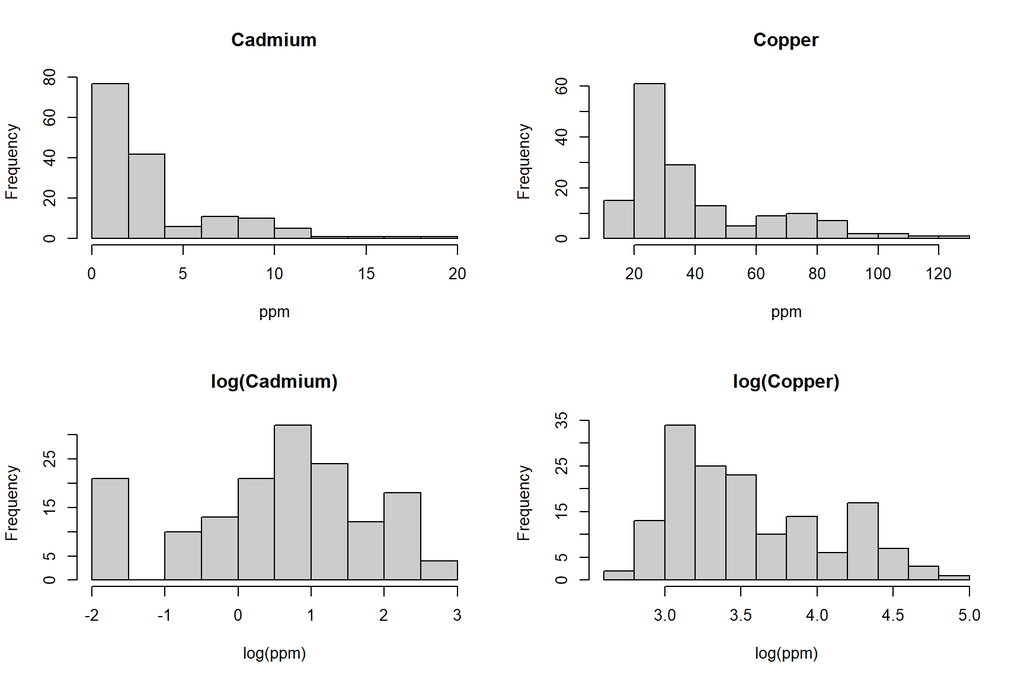

```r
par(mfrow = c(2, 2))
hist(cd_sf$cadmium, main = "Cadmium", xlab = "ppm", col = "grey80")
hist(cd_sf$copper, main = "Copper", xlab = "ppm", col = "grey80")
hist(log(cd_sf$cadmium), main = "log(Cadmium)", xlab = "log(ppm)", col = "grey80")
hist(log(cd_sf$copper), main = "log(Copper)", xlab = "log(ppm)", col = "grey80")
```

```r
cor(cd_sf$cadmium, cd_sf$copper)
```

```
[1] 0.9254499
```

```r
cor(log(cd_sf$cadmium), log(cd_sf$copper))
```

```
[1] 0.8363329
```

- As with lead and zinc, both variables are very right-skewed, and the log transformation makes their distributions more symmetric. We will work on the **log scale**.
- The correlation between both variables on the log scale is high (0.84), so copper is a promising secondary variable. However, it is lower than the correlation between lead and zinc (0.97).

## 4.2 Semivariogram of the primary variable

Compute the empirical semivariogram of `log(cadmium)` and fit a spherical model with a nugget effect. Choose the initial values by visual inspection of the empirical semivariogram.

**TipSolution**

```r
v_cd <- variogram(log(cadmium) ~ 1, cd_sf)
vgm_cd <- fit.variogram(v_cd, model=vgm(psill=1.5, model="Sph",
                                        range=1000, nugget=0.5))
vgm_cd
```

```
  model     psill    range
1   Nug 0.5478481    0.000
2   Sph 1.3397973 1149.438
```

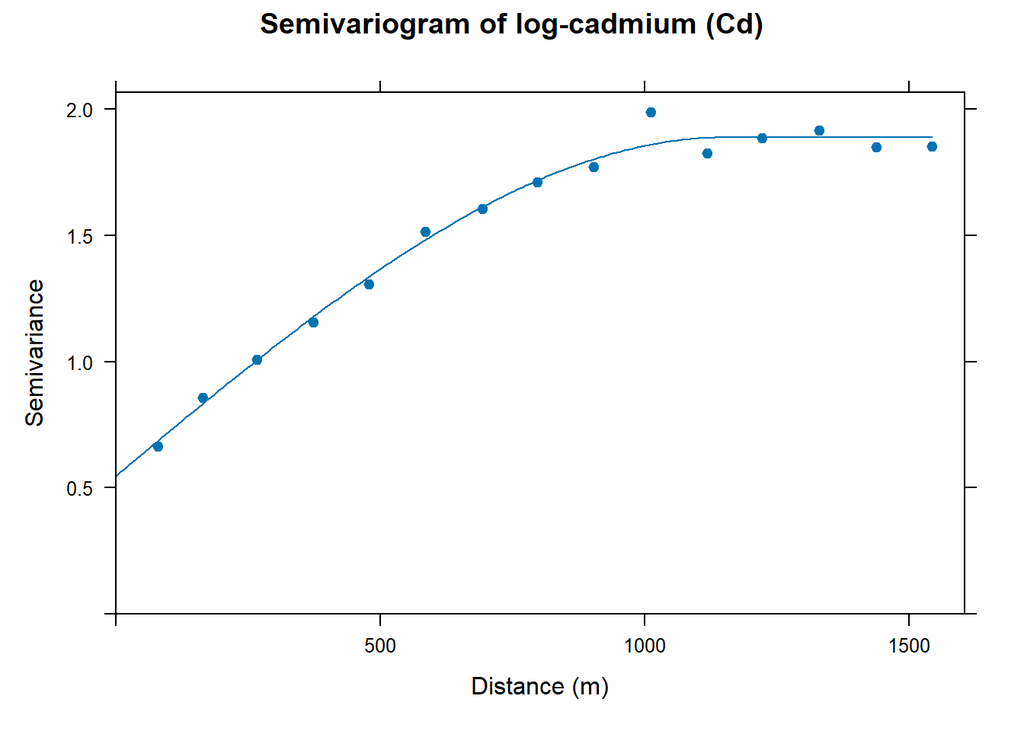

```r
plot(v_cd, vgm_cd, pch = 19,
     xlab = "Distance (m)", ylab = "Semivariance",
     main = "Semivariogram of log-cadmium (Cd)")
```

- Nugget effect $\approx$ 0.55, partial sill $\approx$ 1.34 and range $\approx$ 1149 m.
- The nugget effect represents about 29% of the total sill, much more than for lead: cadmium shows more variability at very short distances.

## 4.3 Linear model of coregionalization

Create a `gstat` object with both variables, compute the direct and cross empirical semivariograms and fit a linear model of coregionalization.

- Is the cross-semivariogram structured?

**TipSolution**

```r
g <- gstat(NULL, id = "Cd", formula = log(cadmium) ~ 1, data = cd_sf)
g <- gstat(g,    id = "Cu", formula = log(copper) ~ 1,  data = cu_sf)

v <- variogram(g)
lmc <- fit.lmc(v, g, model=vgm_cd)
lmc$model
```

```
$Cd
  model     psill    range
1   Nug 0.5478481    0.000
2   Sph 1.3397973 1149.438

$Cd.Cu
  model     psill    range
1   Nug 0.1533914    0.000
2   Sph 0.5162377 1149.438

$Cu
  model      psill    range
1   Nug 0.08081862    0.000
2   Sph 0.24530645 1149.438
```

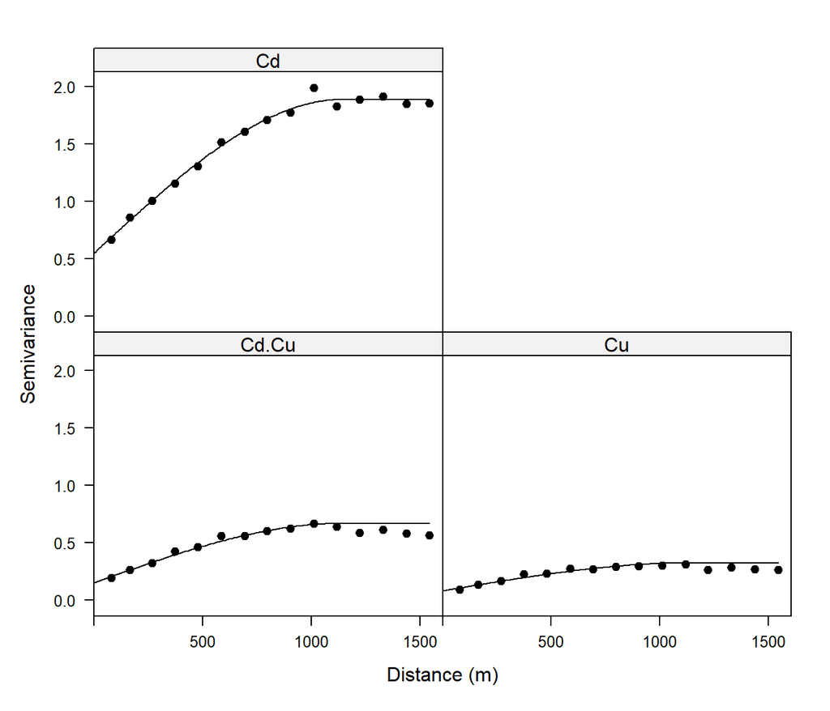

```r
plot(v, lmc, pch = 19, col = "black",
     xlab = "Distance (m)", ylab = "Semivariance",
     scales = list(alternating = 1, tck = c(1, 0)))
```

The cross-semivariogram increases with distance and levels off at about 0.67: there is a clear **spatial correlation** between cadmium and copper.

## 4.4 Predictions

Predict cadmium on the `meuse.grid` nodes using ordinary kriging and co-kriging. Plot the predictions and their standard errors for both methods.

- Are there differences between both methods?

**TipSolution**

```r
pred_krig <- krige(log(cadmium) ~ 1, cd_sf, grid_sf, model=vgm_cd, debug.level=0)
pred_cokrig <- predict(lmc, grid_sf, debug.level=0)

pred_sf <- grid_sf |>
  mutate(krig_pred   = pred_krig$var1.pred,
         krig_sd     = sqrt(pred_krig$var1.var),
         cokrig_pred = pred_cokrig$Cd.pred,
         cokrig_sd   = sqrt(pred_cokrig$Cd.var)) |>
  st_buffer(dist=20, endCapStyle="SQUARE")
```

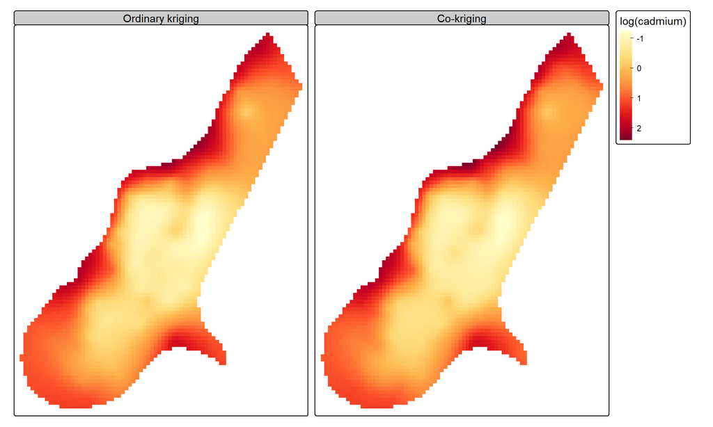

```r
tmap_mode("plot")

# Predictions
tm_shape(pred_sf) +
  tm_polygons(fill = c("krig_pred", "cokrig_pred"),
              fill.scale  = tm_scale_continuous(values = "brewer.yl_or_rd"),
              fill.legend = tm_legend(title = "log(cadmium)"),
              fill.free = FALSE,    # common colour scale
              col = NULL) +         # no cell borders
  tm_facets_wrap(nrow=1) +
  tm_layout(panel.labels = c("Ordinary kriging", "Co-kriging"))
```

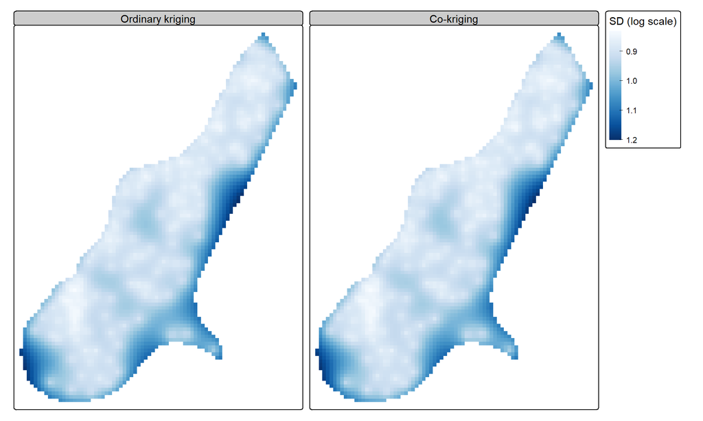

```r
# Standard errors
tm_shape(pred_sf) +
  tm_polygons(fill = c("krig_sd", "cokrig_sd"),
              fill.scale  = tm_scale_continuous(values = "brewer.blues"),
              fill.legend = tm_legend(title = "SD (log scale)"),
              fill.free = FALSE,
              col = NULL) +
  tm_facets_wrap(nrow=1) +
  tm_layout(panel.labels = c("Ordinary kriging", "Co-kriging"))
```

- Both prediction maps are very similar.
- The standard errors of co-kriging are only slightly lower: the median standard error decreases from 0.917 to 0.914.

## 4.5 Cross-validation

Compare both methods using leave-one-out cross-validation. Compute the mean absolute error (MAE) and the root mean squared error (RMSE). Plot the observed values against the cross-validation predictions for both methods.

- Does co-kriging improve on ordinary kriging?
- Why is the improvement so small, if the correlation between cadmium and copper is high?

**TipSolution**

```r
# Ordinary kriging
cv_krig <- krige.cv(log(cadmium) ~ 1, cd_sf, model=vgm_cd, nfold=nrow(cd_sf),
                    debug.level=0)

# Co-kriging
cv_cokrig <- gstat.cv(lmc, nfold=nrow(cd_sf), remove.all=TRUE, debug.level=0)

cv_results <- data.frame(
  Method = c("Ordinary kriging", "Co-kriging"),
  MAE    = c(mean(abs(cv_krig$residual)), mean(abs(cv_cokrig$residual))),
  RMSE   = c(sqrt(mean(cv_krig$residual^2)), sqrt(mean(cv_cokrig$residual^2)))
)
cv_results |> mutate(across(c(MAE, RMSE), \(x) round(x, 3)))
```

```
            Method   MAE  RMSE
1 Ordinary kriging 0.664 0.901
2       Co-kriging 0.652 0.888
```

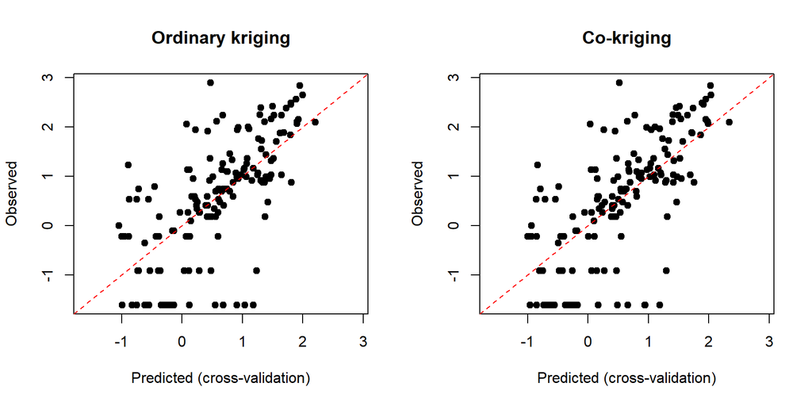

```r
lims <- range(c(cv_krig$observed, cv_krig$var1.pred, cv_cokrig$Cd.pred))

par(mfrow = c(1, 2))
plot(cv_krig$var1.pred, cv_krig$observed, pch = 19, xlim = lims, ylim = lims,
     xlab = "Predicted (cross-validation)", ylab = "Observed",
     main = "Ordinary kriging")
abline(0, 1, lty = 2, col = "red")
plot(cv_cokrig$Cd.pred, cv_cokrig$observed, pch = 19, xlim = lims, ylim = lims,
     xlab = "Predicted (cross-validation)", ylab = "Observed",
     main = "Co-kriging")
abline(0, 1, lty = 2, col = "red")
```

- Co-kriging slightly reduces both errors (the RMSE decreases from 0.901 to 0.888), but the improvement is **very small**. The observed vs. predicted plots are also almost identical.
- The reason is that both variables have been measured at the **same locations**: wherever copper is available, cadmium is also available, so copper provides almost no new spatial information. A high correlation is not enough: co-kriging is most useful when the secondary variable has been observed at many more locations than the primary variable.

# 5 Optional: cadmium observed at 50 locations

To reproduce the typical situation of co-kriging, assume that cadmium has only been measured at a random subset of 50 samples, while copper is still available at all 155 locations:

```r
set.seed(123)
idx <- sample(nrow(meuse_sf), 50)

cd_sf <- meuse_sf |> slice(idx)   # primary variable: 50 samples
cu_sf <- meuse_sf                 # secondary variable: 155 samples
```

Repeat the semivariogram analysis and the cross-validation comparison (maps are not needed). Note that:

- With this sampling design, the zero-distance lag must be removed from the empirical semivariograms before fitting the linear model of coregionalization (see Example 3.2).
- If the co-kriging step returns the error `variograms do not satisfy a legal model`, fit the linear model of coregionalization with the argument `fit.lmc(..., correct.diagonal = 1.01)`.
- Does co-kriging improve on ordinary kriging now?
- Compare the results with those obtained with the 155 samples.

**TipSolution**

```r
# Ordinary kriging
v_cd_50 <- variogram(log(cadmium) ~ 1, cd_sf)
vgm_cd_50 <- fit.variogram(v_cd_50, model=vgm(psill=1.5, model="Sph",
                                              range=1000, nugget=0.5))
cv_krig_50 <- krige.cv(log(cadmium) ~ 1, cd_sf, model=vgm_cd_50, nfold=nrow(cd_sf),
                       debug.level=0)

# Co-kriging
g_50 <- gstat(NULL, id = "Cd", formula = log(cadmium) ~ 1, data = cd_sf)
g_50 <- gstat(g_50, id = "Cu", formula = log(copper) ~ 1,  data = cu_sf)
v_50 <- variogram(g_50) |> filter(dist > 0)    # remove the zero-distance lag
lmc_50 <- fit.lmc(v_50, g_50, model=vgm_cd_50, correct.diagonal=1.01)
cv_cokrig_50 <- gstat.cv(lmc_50, nfold=nrow(cd_sf), remove.all=TRUE, debug.level=0)

cv_results_50 <- data.frame(
  Method = c("Ordinary kriging", "Co-kriging"),
  MAE    = c(mean(abs(cv_krig_50$residual)), mean(abs(cv_cokrig_50$residual))),
  RMSE   = c(sqrt(mean(cv_krig_50$residual^2)), sqrt(mean(cv_cokrig_50$residual^2)))
)
```

**NoteThe argument `correct.diagonal = 1.01`**

The sills fitted by `fit.lmc()` must satisfy the condition $|b_{12}| \le \sqrt{b_{11}\,b_{22}}$ for each basic structure. With this subsample, the fitted sills of the spherical structure lie exactly on the limit of this condition, and `gstat` rejects the model when predicting. The argument `correct.diagonal = 1.01` multiplies the sills of the direct semivariograms by 1.01, so that the condition is strictly satisfied.

Cross-validation results with cadmium observed at all 155 locations (columns 2-3) and at 50 locations (columns 4-5).

| Method | MAE | RMSE | MAE | RMSE |
| --- | --- | --- | --- | --- |
| Ordinary kriging | 0.664 | 0.901 | 0.797 | 1.090 |
| Co-kriging | 0.652 | 0.888 | 0.670 | 0.930 |

- With only 50 cadmium samples, co-kriging **clearly improves** on ordinary kriging: the RMSE decreases from 1.090 to 0.930 (a reduction of about 15%).
- Now copper provides information at 105 locations where cadmium is unknown, which is exactly the situation where co-kriging is worthwhile.
- The errors are larger than with 155 samples, because the semivariogram and the predictions are based on fewer cadmium observations.
- These results depend on the random subsample: with other seeds, the improvement may be larger or smaller (and occasionally co-kriging may even be slightly worse).